# Capstone: Logistical Regression 2

Andrew Knittle

Generated on 2021-07-06

This is a second logistical regression report focusing on **Risk Prediction** instead of diagnosing on whether someone will develop cancer or not. We start the same way we did before of building a model (In this case Logistic using Stepwise-AIC)

[output not shown]

```
FALSE
FALSE Call:
FALSE glm(formula = CASESTAT ~ D24_1 + BENZ_K_FLUOR_1 + BENZ_A_PYRENE_1 +
FALSE     CHRYSENE_1 + IDENO_PYR_1 + PCB138_1 + PCB153_1 + DDE_1 +
FALSE     DDT_1 + DIAZINON_1 + PENTACHLOROPHENOL_1, family = "binomial",
FALSE     data = logDustData)
FALSE
FALSE Deviance Residuals:
FALSE     Min       1Q   Median       3Q      Max
FALSE -1.7663  -1.2341   0.8797   1.0453   1.6567
FALSE
FALSE Coefficients:
FALSE                       Estimate Std. Error z value Pr(>|z|)
FALSE (Intercept)          1.307e+00  3.950e-01   3.308 0.000939 ***
FALSE D24_1               -1.632e-01  7.582e-02  -2.153 0.031346 *
FALSE BENZ_K_FLUOR_1       7.551e-01  3.543e-01   2.131 0.033064 *
FALSE BENZ_A_PYRENE_1      9.870e-01  3.835e-01   2.573 0.010068 *
FALSE CHRYSENE_1          -1.204e+00  3.976e-01  -3.028 0.002465 **
FALSE IDENO_PYR_1         -6.784e-01  3.755e-01  -1.807 0.070775 .
FALSE PCB138_1            -4.276e-01  2.752e-01  -1.554 0.120276
FALSE PCB153_1             5.549e-01  2.797e-01   1.984 0.047284 *
FALSE DDE_1                6.176e-01  1.849e-01   3.341 0.000836 ***
FALSE DDT_1               -2.818e-01  1.194e-01  -2.359 0.018325 *
FALSE DIAZINON_1          -1.779e-01  7.141e-02  -2.491 0.012753 *
FALSE PENTACHLOROPHENOL_1 -4.395e-05  2.969e-05  -1.480 0.138773
FALSE ---
FALSE Signif. codes:  0 '***' 0.001 '**' 0.01 '*' 0.05 '.' 0.1 ' ' 1
FALSE
FALSE (Dispersion parameter for binomial family taken to be 1)
FALSE
FALSE     Null deviance: 1613.0  on 1179  degrees of freedom
FALSE Residual deviance: 1568.4  on 1168  degrees of freedom
FALSE AIC: 1592.4
FALSE
FALSE Number of Fisher Scoring iterations: 4
```

| Model | Error_Rate |
| --- | --- |
| Logistic Model | 0.4084746 |

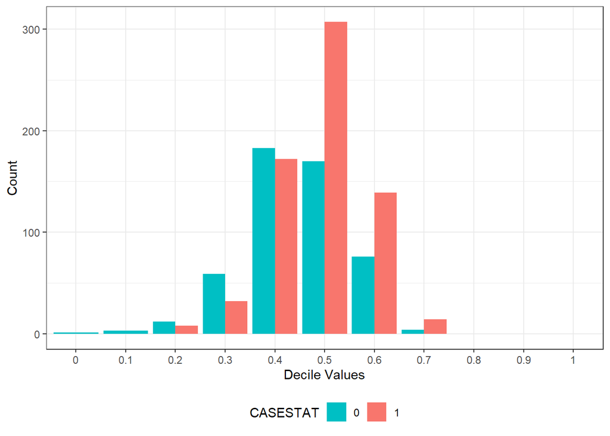

Decile Graph

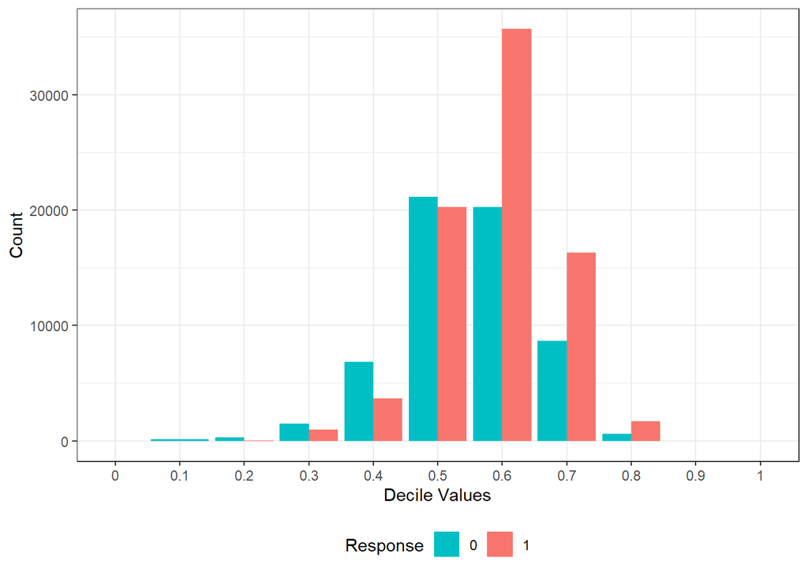

Cross Validation

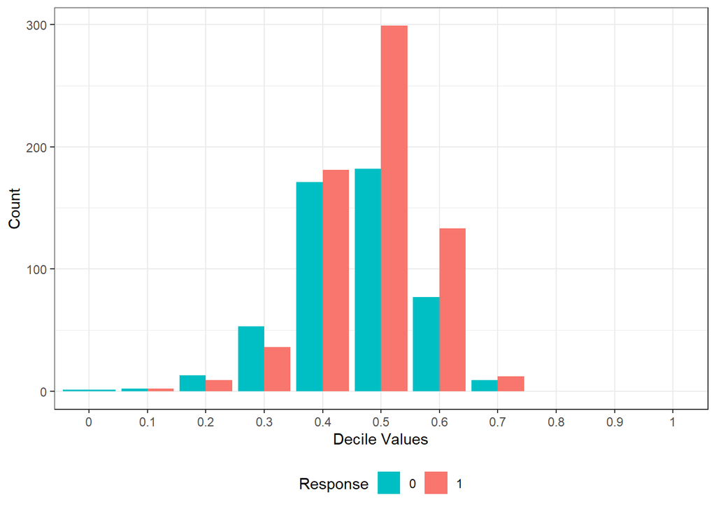

Cross Validation

# Method

Even though Logistic Regression is old hat it’s not bad to review of how it works. A [great write up on Logistic Regression can be found here](https://christophm.github.io/interpretable-ml-book/logistic.html), but I will do my best to summarize without being too dense.

To start off let’s answer why we should use logistic regression, instead of say Linear Regression (for those who already know why, or those who think they’re “too clever” can skip this paragraph). Well Linear Regression tries to answer the question of “given some value of a set of feature(s)/independent variable(s)/predictor(s) what amount will dependent variable/response likely be”. You can probably see already where this is going, but it doesn’t give you a binary, or “yes or no”, result which is what we are looking for in this project. We want to determine if you have cancer, not how much cancer you have.

Logistic Regression models the “*probabilities* for classification problems with two possible outcomes.” In order to do this regression model uses it’s name sake, the logistic function:

$$f(x)=\frac{L}{1+e^{-k(x-x_0)}}$$

- $f(x)$ = output of the function
- $L$ = the curve’s maximum value
- $k$ = logistic growth rate or steepness of the curve
- $x_0$ = the x value of the sigmoid midpoint
- $x$ = real number

To make it into a logistic regression model we take the foundation and tweak it a little to use predictor variables, and since this is for classification purposes we want probabilities between 0 and 1 (so $L=1$).

$$P(y^{i}=1)=\frac{1}{1+e^{-(\beta_0+\beta_1x_1^i+...+\beta_px_p^p)}}$$

Now that our output is in probability, between 0 and 1, the weights are no longer in linear form. The weights/coefficients are now in terms of log odds, “probability of event divided by probability of no event”. This does make interpreting your model obviously pretty difficult since it’s not a simple weighted value for coefficients.